# Проект по A/B тестированию

# Описание проекта и данных

## Описание проекта

**Задача** данного проекта — провести оценку результатов `A/B-теста`. В нашем распоряжении есть датасет с действиями пользователей, техническое задание и несколько вспомогательных датасетов.

Для ответа на поставленную *задачу*, нам будет необходимо проделать следующие шаги:

1. Провести первичный обзор данных;
2. Сделать при необходимости предобратоку данных;
3. Оценить корректность проведения теста, а именно:
   - пересечение тестовой аудитории с конкурирующим тестом,
   - совпадение теста и маркетинговых событий, другие проблемы временных границ теста.
1. Провести исследовательский анализ данных;
2. Оценить результаты `A/B тестирования`;
3. Сделать общий вывод по проделанной работе

## Описание данных

В нашем распоряжении четыре датасета:

**1. ab_project_marketing_events.csv** — календарь маркетинговых событий на 2020 год, имеущая следующую структуру:

- `name` — название маркетингового события;
- `regions` — регионы, в которых будет проводиться рекламная кампания;
- `start_dt` — дата начала кампании;
- `finish_dt` — дата завершения кампании.

**2. final_ab_new_users.csv** — пользователи, зарегистрировавшиеся с 7 по 21 декабря 2020 года, имеущая следующую структуру:

- `user_id` — идентификатор пользователя;
- `first_date` — дата регистрации;
- `region` — регион пользователя;
- `device` — устройство, с которого происходила регистрация.

**3. final_ab_events.csv** — действия новых пользователей в период с 7 декабря 2020 по 4 января 2021 года, имеущая следующую структуру:

- `user_id` — идентификатор пользователя;
- `event_dt` — дата и время события;
- `event_name` — тип события;
- `details` — дополнительные данные о событии. Например, для покупок, `purchase,` в этом поле хранится стоимость покупки в долларах.

**4. final_ab_participants.csv** — таблица участников тестов, имеущая следующую структуру:

- `user_id` — идентификатор пользователя;
- `ab_test` — название теста;
- `group` — группа пользователя.

# Обзор и предобработка данных

## Обзор данных

```python
# Импортируем необходимые библиотеки

import pandas as pd
import numpy as np
import datetime as dt
import scipy.stats as stats
import matplotlib.pyplot as plt
import seaborn as sns
import plotly.express as px
from plotly import graph_objects as go
from plotly.subplots import make_subplots
import math
```

```python
# Для удобства отобразим все колонки таблицы и изменим их ширину

pd.set_option('display.max_columns', None)
pd.set_option('max_colwidth', None)
```

```python
# Указываем путь к файлам и записываем датасеты в переменные

marketing_events = pd.read_csv('ab_project_marketing_events.csv')
new_users = pd.read_csv('final_ab_new_users.csv')
events = pd.read_csv('final_ab_events.csv')
participants = pd.read_csv('final_ab_participants.csv')
```

```python
# Создадим функцию для обзора данных: выведем первые и последние 5 строк, общую информацию, количество и процент пропусков,
# кол-во и долю дубликатов и статистические данные по датафрейму.
# Функция на вход будет принимать датафрейм.

def df_review(data):

    # Выведем первые и последние 5 строк из датафрейму
    print('{0:^125}'.format('Обзор данных датасета'))
    display(data)
    print('-'*120)

    # Выведем общую информацию по датафрейму
    print('{0:^125}'.format('Общая информация по датасету'),end='\n\n')
    data.info()
    print()
    print(f'Датафрейм состоит из {data.shape[0]} строк и {data.shape[1]} колонок')
    print('-'*120)

    # Выведем кол-во и процент пропусков в колонках датафрейма
    print('{0:^125}'.format('Количество пропусков и их доля от всех строк в датасете'))
    # Посчитаем кол-во пропусков и их процент от общего числа строк в датафрейме по каждому столбцу
    num_of_nan = data.isnull().sum().to_frame().reset_index().merge \
    (round(data.isnull().mean()*100,2).to_frame().reset_index(), on='index', how='left')
    # Переимунуем названия колонок для удобства и выведем рез-т
    num_of_nan.columns = ['columns','nan_count','nan_ratio']
    num_of_nan['nan_ratio'] = num_of_nan['nan_ratio'].map('{0:.2f}%'.format)
    display(num_of_nan.sort_values(by='nan_count', ascending=False))
    print('-'*120)

    # Посчитаем кол-во и долю явных дубликатов в датафрейме
    print(f'Количество явных дубликатов в датасете: {data.duplicated().sum()}')
    print (f'Доля явных дубликатов в датасете: {round(100*data.duplicated().sum()/data.shape[0],2)}%')
    print('-'*120,end='\n\n')

    # Выведем информацию по статистическим данным датафрейма
    print('{0:^125}'.format('Обзор cтатистических данных по датасету'))
    display(data.describe())
```

```python
df_review(marketing_events)
```

```
                                                    Обзор данных датасета
```

|  | name | regions | start_dt | finish_dt |
| --- | --- | --- | --- | --- |
| 0 | Christmas&New Year Promo | EU, N.America | 2020-12-25 | 2021-01-03 |
| 1 | St. Valentine's Day Giveaway | EU, CIS, APAC, N.America | 2020-02-14 | 2020-02-16 |
| 2 | St. Patric's Day Promo | EU, N.America | 2020-03-17 | 2020-03-19 |
| 3 | Easter Promo | EU, CIS, APAC, N.America | 2020-04-12 | 2020-04-19 |
| 4 | 4th of July Promo | N.America | 2020-07-04 | 2020-07-11 |
| 5 | Black Friday Ads Campaign | EU, CIS, APAC, N.America | 2020-11-26 | 2020-12-01 |
| 6 | Chinese New Year Promo | APAC | 2020-01-25 | 2020-02-07 |
| 7 | Labor day (May 1st) Ads Campaign | EU, CIS, APAC | 2020-05-01 | 2020-05-03 |
| 8 | International Women's Day Promo | EU, CIS, APAC | 2020-03-08 | 2020-03-10 |
| 9 | Victory Day CIS (May 9th) Event | CIS | 2020-05-09 | 2020-05-11 |
| 10 | CIS New Year Gift Lottery | CIS | 2020-12-30 | 2021-01-07 |
| 11 | Dragon Boat Festival Giveaway | APAC | 2020-06-25 | 2020-07-01 |
| 12 | Single's Day Gift Promo | APAC | 2020-11-11 | 2020-11-12 |
| 13 | Chinese Moon Festival | APAC | 2020-10-01 | 2020-10-07 |

```
------------------------------------------------------------------------------------------------------------------------
                                                Общая информация по датасету

<class 'pandas.core.frame.DataFrame'>
RangeIndex: 14 entries, 0 to 13
Data columns (total 4 columns):
 #   Column     Non-Null Count  Dtype
---  ------     --------------  -----
 0   name       14 non-null     object
 1   regions    14 non-null     object
 2   start_dt   14 non-null     object
 3   finish_dt  14 non-null     object
dtypes: object(4)
memory usage: 576.0+ bytes

Датафрейм состоит из 14 строк и 4 колонок
------------------------------------------------------------------------------------------------------------------------
                                   Количество пропусков и их доля от всех строк в датасете
```

|  | columns | nan_count | nan_ratio |
| --- | --- | --- | --- |
| 0 | name | 0 | 0.00% |
| 1 | regions | 0 | 0.00% |
| 2 | start_dt | 0 | 0.00% |
| 3 | finish_dt | 0 | 0.00% |

```
------------------------------------------------------------------------------------------------------------------------
Количество явных дубликатов в датасете: 0
Доля явных дубликатов в датасете: 0.0%
------------------------------------------------------------------------------------------------------------------------

                                           Обзор cтатистических данных по датасету
```

|  | name | regions | start_dt | finish_dt |
| --- | --- | --- | --- | --- |
| count | 14 | 14 | 14 | 14 |
| unique | 14 | 6 | 14 | 14 |
| top | Single's Day Gift Promo | APAC | 2020-03-08 | 2020-02-07 |
| freq | 1 | 4 | 1 | 1 |

После первичного обзора данных в датафрейме `marketing_events`, мы видим, что с данными все в порядке, за исключением некорректного типа данных для колонок `start_dt` и `finish_dt`.

```python
df_review(new_users)
```

```
                                                    Обзор данных датасета
```

|  | user_id | first_date | region | device |
| --- | --- | --- | --- | --- |
| 0 | D72A72121175D8BE | 2020-12-07 | EU | PC |
| 1 | F1C668619DFE6E65 | 2020-12-07 | N.America | Android |
| 2 | 2E1BF1D4C37EA01F | 2020-12-07 | EU | PC |
| 3 | 50734A22C0C63768 | 2020-12-07 | EU | iPhone |
| 4 | E1BDDCE0DAFA2679 | 2020-12-07 | N.America | iPhone |
| ... | ... | ... | ... | ... |
| 61728 | 1DB53B933257165D | 2020-12-20 | EU | Android |
| 61729 | 538643EB4527ED03 | 2020-12-20 | EU | Mac |
| 61730 | 7ADEE837D5D8CBBD | 2020-12-20 | EU | PC |
| 61731 | 1C7D23927835213F | 2020-12-20 | EU | iPhone |
| 61732 | 8F04273BB2860229 | 2020-12-20 | EU | Android |

61733 rows × 4 columns

```
------------------------------------------------------------------------------------------------------------------------
                                                Общая информация по датасету

<class 'pandas.core.frame.DataFrame'>
RangeIndex: 61733 entries, 0 to 61732
Data columns (total 4 columns):
 #   Column      Non-Null Count  Dtype
---  ------      --------------  -----
 0   user_id     61733 non-null  object
 1   first_date  61733 non-null  object
 2   region      61733 non-null  object
 3   device      61733 non-null  object
dtypes: object(4)
memory usage: 1.9+ MB

Датафрейм состоит из 61733 строк и 4 колонок
------------------------------------------------------------------------------------------------------------------------
                                   Количество пропусков и их доля от всех строк в датасете
```

|  | columns | nan_count | nan_ratio |
| --- | --- | --- | --- |
| 0 | user_id | 0 | 0.00% |
| 1 | first_date | 0 | 0.00% |
| 2 | region | 0 | 0.00% |
| 3 | device | 0 | 0.00% |

```
------------------------------------------------------------------------------------------------------------------------
Количество явных дубликатов в датасете: 0
Доля явных дубликатов в датасете: 0.0%
------------------------------------------------------------------------------------------------------------------------

                                           Обзор cтатистических данных по датасету
```

|  | user_id | first_date | region | device |
| --- | --- | --- | --- | --- |
| count | 61733 | 61733 | 61733 | 61733 |
| unique | 61733 | 17 | 4 | 4 |
| top | 709243A7B8E50E95 | 2020-12-21 | EU | Android |
| freq | 1 | 6290 | 46270 | 27520 |

Аналогично все и с датафреймом `new_users`, неверный тип данных для колонки `first_date`.

```python
df_review(events)
```

```
                                                    Обзор данных датасета
```

|  | user_id | event_dt | event_name | details |
| --- | --- | --- | --- | --- |
| 0 | E1BDDCE0DAFA2679 | 2020-12-07 20:22:03 | purchase | 99.99 |
| 1 | 7B6452F081F49504 | 2020-12-07 09:22:53 | purchase | 9.99 |
| 2 | 9CD9F34546DF254C | 2020-12-07 12:59:29 | purchase | 4.99 |
| 3 | 96F27A054B191457 | 2020-12-07 04:02:40 | purchase | 4.99 |
| 4 | 1FD7660FDF94CA1F | 2020-12-07 10:15:09 | purchase | 4.99 |
| ... | ... | ... | ... | ... |
| 440312 | 245E85F65C358E08 | 2020-12-30 19:35:55 | login | NaN |
| 440313 | 9385A108F5A0A7A7 | 2020-12-30 10:54:15 | login | NaN |
| 440314 | DB650B7559AC6EAC | 2020-12-30 10:59:09 | login | NaN |
| 440315 | F80C9BDDEA02E53C | 2020-12-30 09:53:39 | login | NaN |
| 440316 | 7AEC61159B672CC5 | 2020-12-30 11:36:13 | login | NaN |

440317 rows × 4 columns

```
------------------------------------------------------------------------------------------------------------------------
                                                Общая информация по датасету

<class 'pandas.core.frame.DataFrame'>
RangeIndex: 440317 entries, 0 to 440316
Data columns (total 4 columns):
 #   Column      Non-Null Count   Dtype
---  ------      --------------   -----
 0   user_id     440317 non-null  object
 1   event_dt    440317 non-null  object
 2   event_name  440317 non-null  object
 3   details     62740 non-null   float64
dtypes: float64(1), object(3)
memory usage: 13.4+ MB

Датафрейм состоит из 440317 строк и 4 колонок
------------------------------------------------------------------------------------------------------------------------
                                   Количество пропусков и их доля от всех строк в датасете
```

|  | columns | nan_count | nan_ratio |
| --- | --- | --- | --- |
| 3 | details | 377577 | 85.75% |
| 0 | user_id | 0 | 0.00% |
| 1 | event_dt | 0 | 0.00% |
| 2 | event_name | 0 | 0.00% |

```
------------------------------------------------------------------------------------------------------------------------
Количество явных дубликатов в датасете: 0
Доля явных дубликатов в датасете: 0.0%
------------------------------------------------------------------------------------------------------------------------

                                           Обзор cтатистических данных по датасету
```

|  | details |
| --- | --- |
| count | 62740.000000 |
| mean | 23.877631 |
| std | 72.180465 |
| min | 4.990000 |
| 25% | 4.990000 |
| 50% | 4.990000 |
| 75% | 9.990000 |
| max | 499.990000 |

```python
df_review(participants)
```

```
                                                    Обзор данных датасета
```

|  | user_id | group | ab_test |
| --- | --- | --- | --- |
| 0 | D1ABA3E2887B6A73 | A | recommender_system_test |
| 1 | A7A3664BD6242119 | A | recommender_system_test |
| 2 | DABC14FDDFADD29E | A | recommender_system_test |
| 3 | 04988C5DF189632E | A | recommender_system_test |
| 4 | 482F14783456D21B | B | recommender_system_test |
| ... | ... | ... | ... |
| 18263 | 1D302F8688B91781 | B | interface_eu_test |
| 18264 | 3DE51B726983B657 | A | interface_eu_test |
| 18265 | F501F79D332BE86C | A | interface_eu_test |
| 18266 | 63FBE257B05F2245 | A | interface_eu_test |
| 18267 | 79F9ABFB029CF724 | B | interface_eu_test |

18268 rows × 3 columns

```
------------------------------------------------------------------------------------------------------------------------
                                                Общая информация по датасету

<class 'pandas.core.frame.DataFrame'>
RangeIndex: 18268 entries, 0 to 18267
Data columns (total 3 columns):
 #   Column   Non-Null Count  Dtype
---  ------   --------------  -----
 0   user_id  18268 non-null  object
 1   group    18268 non-null  object
 2   ab_test  18268 non-null  object
dtypes: object(3)
memory usage: 428.3+ KB

Датафрейм состоит из 18268 строк и 3 колонок
------------------------------------------------------------------------------------------------------------------------
                                   Количество пропусков и их доля от всех строк в датасете
```

|  | columns | nan_count | nan_ratio |
| --- | --- | --- | --- |
| 0 | user_id | 0 | 0.00% |
| 1 | group | 0 | 0.00% |
| 2 | ab_test | 0 | 0.00% |

```
------------------------------------------------------------------------------------------------------------------------
Количество явных дубликатов в датасете: 0
Доля явных дубликатов в датасете: 0.0%
------------------------------------------------------------------------------------------------------------------------

                                           Обзор cтатистических данных по датасету
```

|  | user_id | group | ab_test |
| --- | --- | --- | --- |
| count | 18268 | 18268 | 18268 |
| unique | 16666 | 2 | 2 |
| top | FEC0BCA6C323872F | A | interface_eu_test |
| freq | 2 | 9655 | 11567 |

С данными в `participants` предобработка не требуется.

В дальнейшей предобработке данных, приведем колонки к нужному типу данных и разберемся с пропусками в датафрейме `events`.

## Предобработка данных

```python
# Изменим в колонках тип данных на datetime

marketing_events['start_dt'] = pd.to_datetime(marketing_events['start_dt'])
marketing_events['finish_dt'] = pd.to_datetime(marketing_events['finish_dt'])
new_users['first_date'] = pd.to_datetime(new_users['first_date'])
events['event_dt'] = pd.to_datetime(pd.to_datetime(events['event_dt']).dt.date)
```

```python
# Так как details показывает дополнительные данные о событии event_name, посчтиаем кол-во заполненных данных по каждому из них
events.groupby('event_name')['details'].count().reset_index()
```

|  | event_name | details |
| --- | --- | --- |
| 0 | login | 0 |
| 1 | product_cart | 0 |
| 2 | product_page | 0 |
| 3 | purchase | 62740 |

Мы видим, что заполнены данные только по событию `purchase`. Так как эти данные в дальнейшем анализе ни на что не повлияют, оставим все как есть.

# Оценка корректности проведения теста

Для оценки корректности проведения теста мы должны убедиться, что данные соответствуют требованиям **технического задания**, а именно:

- Название теста: `recommender_system_test`;
- группы: А — контрольная, B — новая платёжная воронка;
- аудиторию теста. Проверить, есть ли пересечения с конкурирующим тестом и нет ли пользователей, участвующих в двух группах теста одновременно. Проверить равномерность распределения по тестовым группам и правильность их формирования.
- дата запуска: 2020-12-07;
- дата остановки набора новых пользователей: 2020-12-21;
- дата остановки: 2021-01-04;
- время проведения теста. Проверить, что оно не совпадает с маркетинговыми и другими активностями;
- аудитория: 15% новых пользователей из региона EU;
- назначение теста: тестирование изменений, связанных с внедрением улучшенной рекомендательной системы;
- ожидаемое количество участников теста: 6000.
- ожидаемый эффект: за 14 дней с момента регистрации пользователи покажут улучшение каждой метрики не менее, чем на 10%:
  - конверсии в просмотр карточек товаров — событие `product_page`,
  - просмотры корзины — `product_cart`,
  - покупки — `purchase`.

## Название теста и проверка групп на пересечение

```python
participants.groupby(['ab_test', 'group']).agg({'user_id': 'nunique'}).reset_index()
```

|  | ab_test | group | user_id |
| --- | --- | --- | --- |
| 0 | interface_eu_test | A | 5831 |
| 1 | interface_eu_test | B | 5736 |
| 2 | recommender_system_test | A | 3824 |
| 3 | recommender_system_test | B | 2877 |

Датасет состоит из двух различных тестов:

- `recommender_system_test` - тестирование изменений, связанных с внедрением улучшенной рекомендательной системы;
- `interface_eu_test` - конкурирующий тест.

В обоих тестах присутствует как контрольная, так и экспериментальная группы, но мы видим, что в нашем тесте `recommender_system_test` неравномерное распределение по группам, кол-во участников `группы A` превышает `группу B` на **947** участника или **32%** (возможно в двух группах присутствуют одновременно несколько пользователей, проверим это).

```python
# Смотрим, есть ли пользователи, которые состоят одновременно в двух группах recommender_system_test

(participants.query('ab_test == "recommender_system_test"')
             .groupby('user_id')
             .agg({'group':'nunique'})
             .query('group > 1')
)
```

|  | group |
| --- | --- |
| user_id |  |

Все пользователи в обеих группах теста `recommender_system_test` уникальные и не пересекаются.

Далее проверим, пересекаются ли пользователи `recommender_system_test` с пользователями из `interface_eu_test`.

```python
# Посчтитаем кол-во пользователей, которые находятся в двух тестах и выведем рез-т

intersecting_users = (participants
                          .groupby('user_id')
                          .agg({'ab_test':'nunique'})
                          .query('ab_test > 1')
                          .reset_index()
                     )

print(f' Кол-во пересекающихся пользователей в обоих тестах - {len(intersecting_users)} пользователя')
```

```
 Кол-во пересекающихся пользователей в обоих тестах - 1602 пользователя
```

```python
intersecting_users
```

|  | user_id | ab_test |
| --- | --- | --- |
| 0 | 001064FEAAB631A1 | 2 |
| 1 | 00341D8401F0F665 | 2 |
| 2 | 003B6786B4FF5B03 | 2 |
| 3 | 0082295A41A867B5 | 2 |
| 4 | 00E68F103C66C1F7 | 2 |
| ... | ... | ... |
| 1597 | FF7BE2897FC0380D | 2 |
| 1598 | FF9A81323FA67D6E | 2 |
| 1599 | FFC53FD45DDA5EE8 | 2 |
| 1600 | FFED90241D04503F | 2 |
| 1601 | FFF28D02B1EACBE1 | 2 |

1602 rows × 2 columns

Мы видим, что одновременно в двух тестах участвуют `1602` пользователя, что не соответсвует поставленному ТЗ. Будет целесообразней этих пользователей удалить из теста, потому что их наличие в наборе данных не даст нам однозначно ответить на вопрос о влиянии на действия пользователей.

```python
# Создаем список с user_id участников теста recommender_system_test с учетом пересекающихся в двух тестах и без
list_users = participants.query('ab_test == "recommender_system_test"')['user_id']
not_intersect_list_users = participants.query('ab_test == "recommender_system_test" and user_id not in @intersecting_users.user_id')['user_id']

# Создаем список из юзеров состоящих только в тесте recommender_system_test
list_users_rst = new_users.query('user_id in @not_intersect_list_users')['user_id']

# Фильтруем датафреймы по юзером, состоящих только в тесте recommender_system_test
events_rst = events.query('user_id in @list_users_rst')
new_users_rst = new_users.query('user_id in @list_users_rst')
```

## Дата запуска, остановки теста и набора новых пользователей и пересечение с маркетинговыми активностями

```python
# Выводим даты

print(f'Дата запуска теста - {events_rst["event_dt"].min()}')
print(f'Дата остановки теста - {events_rst["event_dt"].max()}')
print(f'Дата остановки набора новых пользователей - {new_users_rst["first_date"].max()}')
```

```
Дата запуска теста - 2020-12-07 00:00:00
Дата остановки теста - 2020-12-30 00:00:00
Дата остановки набора новых пользователей - 2020-12-21 00:00:00
```

Как мы видим, техническому заданию:

- Соответствуют - `дата запуска теста` и `дата остановки набора новых пользователей`;
- Не соответствует - `дата остановки теста`, которая должна была наступить `2021-01-04`, а по факту - `2020-12-30` (раньше на 5 дней).

По нашему ТЗ лайфтам действия должен был быть не более `14 дней`, то есть действие пользователем должно было быть совершено в течение `14 дней` с момента регистрации. Для соотвествия ТЗ оставим только те события, которые подходят этому условию. Для начала создадим объединенный датафрейм по подходящим для нашего дальнейшего анализа юзерам.

```python
# Создаем один объединенный датафрейм
df = (new_users_rst
      .merge(events, how='left', left_on='user_id', right_on='user_id')
      .merge(participants, how='left', left_on='user_id', right_on='user_id')
     )

# Выведем рез-т
df
```

|  | user_id | first_date | region | device | event_dt | event_name | details | group | ab_test |
| --- | --- | --- | --- | --- | --- | --- | --- | --- | --- |
| 0 | D72A72121175D8BE | 2020-12-07 | EU | PC | 2020-12-07 | product_page | NaN | A | recommender_system_test |
| 1 | D72A72121175D8BE | 2020-12-07 | EU | PC | 2020-12-07 | login | NaN | A | recommender_system_test |
| 2 | 831887FE7F2D6CBA | 2020-12-07 | EU | Android | 2020-12-07 | purchase | 4.99 | A | recommender_system_test |
| 3 | 831887FE7F2D6CBA | 2020-12-07 | EU | Android | 2020-12-09 | purchase | 99.99 | A | recommender_system_test |
| 4 | 831887FE7F2D6CBA | 2020-12-07 | EU | Android | 2020-12-07 | product_cart | NaN | A | recommender_system_test |
| ... | ... | ... | ... | ... | ... | ... | ... | ... | ... |
| 21110 | 0416B34D35C8C8B8 | 2020-12-20 | EU | Android | 2020-12-24 | product_page | NaN | A | recommender_system_test |
| 21111 | 0416B34D35C8C8B8 | 2020-12-20 | EU | Android | 2020-12-20 | login | NaN | A | recommender_system_test |
| 21112 | 0416B34D35C8C8B8 | 2020-12-20 | EU | Android | 2020-12-21 | login | NaN | A | recommender_system_test |
| 21113 | 0416B34D35C8C8B8 | 2020-12-20 | EU | Android | 2020-12-24 | login | NaN | A | recommender_system_test |
| 21114 | 89CB0BFBC3F35126 | 2020-12-20 | EU | PC | NaT | NaN | NaN | B | recommender_system_test |

21115 rows × 9 columns

Мы видим, что у некоторых пользователей нет данных по совершаемым событиям, отфильтруем данные и посмотрим сколько таких строк

```python
# Смотрим на эти пропуски
df[df.event_dt.isna()]
```

|  | user_id | first_date | region | device | event_dt | event_name | details | group | ab_test |
| --- | --- | --- | --- | --- | --- | --- | --- | --- | --- |
| 37 | 16C69ED14DA9F4A8 | 2020-12-07 | EU | PC | NaT | NaN | NaN | B | recommender_system_test |
| 41 | 2420EA89BB4BB0EA | 2020-12-07 | EU | iPhone | NaT | NaN | NaN | A | recommender_system_test |
| 42 | 4D851A41ECF4440F | 2020-12-07 | EU | Android | NaT | NaN | NaN | B | recommender_system_test |
| 82 | 8EB0C7622C73BBA3 | 2020-12-07 | EU | Android | NaT | NaN | NaN | A | recommender_system_test |
| 98 | CC4AB3D82E6B0C22 | 2020-12-07 | EU | PC | NaT | NaN | NaN | A | recommender_system_test |
| ... | ... | ... | ... | ... | ... | ... | ... | ... | ... |
| 21027 | 7EA72BCB46012967 | 2020-12-20 | EU | iPhone | NaT | NaN | NaN | B | recommender_system_test |
| 21041 | 1942FB76074AA16F | 2020-12-20 | EU | PC | NaT | NaN | NaN | B | recommender_system_test |
| 21042 | 6670B7F8E44E51A9 | 2020-12-20 | EU | Android | NaT | NaN | NaN | B | recommender_system_test |
| 21081 | FB99C8676FAF89A7 | 2020-12-20 | EU | PC | NaT | NaN | NaN | B | recommender_system_test |
| 21114 | 89CB0BFBC3F35126 | 2020-12-20 | EU | PC | NaT | NaN | NaN | B | recommender_system_test |

2311 rows × 9 columns

Посчитаем кол-во действий, которые совершали данные юзеры

```python
# Считаем кол-во событий у этих пол-телей
df[df.event_dt.isna()].groupby('user_id',as_index=False)['first_date'].count()
```

|  | user_id | first_date |
| --- | --- | --- |
| 0 | 000ABE35EE11412F | 1 |
| 1 | 001C05E87D336C59 | 1 |
| 2 | 006D4BE0C4EA616F | 1 |
| 3 | 007B7DE3A2E44050 | 1 |
| 4 | 0080F3BC48BBC85E | 1 |
| ... | ... | ... |
| 2306 | FF547172851FB1EE | 1 |
| 2307 | FF6B409A73E7B239 | 1 |
| 2308 | FFB3F647898BA928 | 1 |
| 2309 | FFC2C5F898D1245B | 1 |
| 2310 | FFE858A7845F005E | 1 |

2311 rows × 2 columns

Мы видим, что абсолютно все эти юзеры по факту совершили только одно действие и скорее всего это просто регистрация. Пользователи могли быть зарегистрированы по заявке или в рамках какой-то кампании и больше вообще никак не взаимодействовать с сайтом, мы не можем точно ответить на этот вопрос, но должны их учитывать при построении воронки событий (иначе отпадут еще `2311` юзеров при ее построении).

Поэтому для каждого такого пользователя в колонку с `event_dt` будет соотвествовать дата из колонки `first_date`, что будет означать как событие регистрации.

```python
# Заполняем пропуски
df['event_dt'] = df['event_dt'].fillna(df['first_date'])
```

```python
# Считаем лайфтам для каждого события и оставляем только те, которые не превышают 14 дней
df['lifetime'] = (df['event_dt'] - df['first_date']).dt.days
df = df.query('lifetime <= 14')

# Посмотрим, что осталось в итоге
df
```

|  | user_id | first_date | region | device | event_dt | event_name | details | group | ab_test | lifetime |
| --- | --- | --- | --- | --- | --- | --- | --- | --- | --- | --- |
| 0 | D72A72121175D8BE | 2020-12-07 | EU | PC | 2020-12-07 | product_page | NaN | A | recommender_system_test | 0 |
| 1 | D72A72121175D8BE | 2020-12-07 | EU | PC | 2020-12-07 | login | NaN | A | recommender_system_test | 0 |
| 2 | 831887FE7F2D6CBA | 2020-12-07 | EU | Android | 2020-12-07 | purchase | 4.99 | A | recommender_system_test | 0 |
| 3 | 831887FE7F2D6CBA | 2020-12-07 | EU | Android | 2020-12-09 | purchase | 99.99 | A | recommender_system_test | 2 |
| 4 | 831887FE7F2D6CBA | 2020-12-07 | EU | Android | 2020-12-07 | product_cart | NaN | A | recommender_system_test | 0 |
| ... | ... | ... | ... | ... | ... | ... | ... | ... | ... | ... |
| 21110 | 0416B34D35C8C8B8 | 2020-12-20 | EU | Android | 2020-12-24 | product_page | NaN | A | recommender_system_test | 4 |
| 21111 | 0416B34D35C8C8B8 | 2020-12-20 | EU | Android | 2020-12-20 | login | NaN | A | recommender_system_test | 0 |
| 21112 | 0416B34D35C8C8B8 | 2020-12-20 | EU | Android | 2020-12-21 | login | NaN | A | recommender_system_test | 1 |
| 21113 | 0416B34D35C8C8B8 | 2020-12-20 | EU | Android | 2020-12-24 | login | NaN | A | recommender_system_test | 4 |
| 21114 | 89CB0BFBC3F35126 | 2020-12-20 | EU | PC | 2020-12-20 | NaN | NaN | B | recommender_system_test | 0 |

20640 rows × 10 columns

Далее проверим проводились ли какие-либо маркетинговые активновсти в период проведения теста.

```python
marketing_events.query('start_dt >= "2020-12-07" and finish_dt <= "2021-01-04"')
```

|  | name | regions | start_dt | finish_dt |
| --- | --- | --- | --- | --- |
| 0 | Christmas&New Year Promo | EU, N.America | 2020-12-25 | 2021-01-03 |

Мы можем наблюдать, что с `2020-12-25` по `2021-01-03` проводится маркетинговая кампания `Christmas&New Year Promo`, которая связана с Новым Годом и Рождеством.

Опять-таки, это может сказаться на поведении пользователей в этот период и не дать однозначного ответа, что конкретно повлияло на совершение действий в этот период, но мы уже и так отсеяли большое кол-во пользователей.

Поэтому оценим реальную небходимость удаления пользователей, зарегистрировавшихся в начало и после промоакции.

```python
# Создадим датасет, который соотвествует периоду проведения промоакции
df_promo = df.query('event_dt >= "2020-12-25"')

# Посчитаем кол-во пользователей и событий в каждой группе за этот период
promo_pivot = (df_promo
               .groupby('group')
               .agg({'user_id':'nunique',
                     'event_name':'count'})
               .rename(columns={'user_id':'users_num',
                                'event_name':'events_num'})
               .reset_index()
              )

# Выведем рез-т
display(promo_pivot)

# Посчитаем долю этих событий по отношению ко всему периоду и выведем рез-т
promo_events_share = '{0:.2%}'.format(promo_pivot['events_num'].sum()/len(df))

print(f'Всего событий в пересечении с промо-периодом - {promo_pivot["events_num"].sum()}, \
что составляет {promo_events_share} от всех событий за анализируемый период.')
```

|  | group | users_num | events_num |
| --- | --- | --- | --- |
| 0 | A | 661 | 1879 |
| 1 | B | 114 | 258 |

```
Всего событий в пересечении с промо-периодом - 2137, что составляет 10.35% от всех событий за анализируемый период.
```

Большая часть событий и пользователей в этот период приходится на контрольную `группу A` (более чем в **5 раз** превышает `группу B`) и доля этих событий от всех за анализируемый период составляет `10.35%`. Поэтому, будем считать влияние промо-периода на тест не столь значительным, как те критерии, что мы виделили ранее и оставим отфильтрованный нами датастет в том же виде.

## Проверка кол-ва участников теста и аудитории в 15% новых пользователей из EU

```python
print(f' Количество участников теста по исходным данным составляет - {len(new_users.query("user_id in @list_users"))} пользователя.')
print(f' Количество участников теста после фильтрации составляет - {len(new_users_rst)} пользователя.')
```

```
 Количество участников теста по исходным данным составляет - 6701 пользователя.
 Количество участников теста после фильтрации составляет - 5099 пользователя.
```

```python
# Считаем кол-во новых пользователей и всего из EU по исходным и отфилтрованным данным
eu_users = len(new_users.query('user_id in @list_users and region == "EU"'))
new_eu_users = len(df.query('region == "EU"')['user_id'].unique())
total_eu_users = len(new_users.query('region == "EU"'))

# Считаем долю новых пользователей из EU по исходным и отфильтрованным данным
eu_users_ratio =  "{:.1%}".format(eu_users/total_eu_users)
new_eu_users_ratio =  "{:.1%}".format(new_eu_users/total_eu_users)

# Выводим рез-т
print(f'Кол-во участников теста из EU по исходным данным - {eu_users},что составляет {eu_users_ratio} \
новых юзеров из EU от необходимых 15% по ТЗ')

print(f'Кол-во участников теста из EU по отфильтрованным данным - {new_eu_users},что составляет {new_eu_users_ratio} \
новых юзеров из EU от необходимых 15% по ТЗ')
```

```
Кол-во участников теста из EU по исходным данным - 6351,что составляет 13.7% новых юзеров из EU от необходимых 15% по ТЗ
Кол-во участников теста из EU по отфильтрованным данным - 4749,что составляет 10.3% новых юзеров из EU от необходимых 15% по ТЗ
```

Мы видим, что условия ТЗ по кол-ву участников теста по исходным данным соответсвует заявленным `6000`, но процент новых пользователей из EU не достигает `15%`.

По очищенными нами данными условия не соблюдаются, кол-во юзеров - `5099` ниже ожидаемых `6000`, и доля новых юзеров из EU составляет `10.3%` при необходимых `15%` (так как мы пытаемся получить более адекватные результаты теста, нами было принятно решение остановиться именно на этом варианте, по причинам описанным в разделах выше)

# Исследовательский анализ данных

## Распределение событий на пользователя в группах

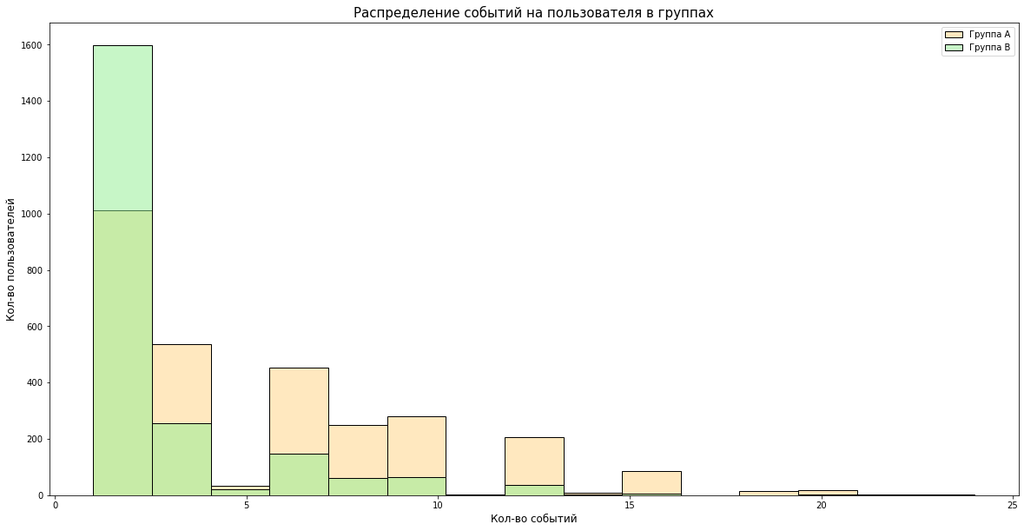

```python
# Подготовим данные для графика
group_a_events = df.query('group=="A"').groupby('user_id', as_index=False)['event_dt'].count()
group_b_events = df.query('group=="B"').groupby('user_id', as_index=False)['event_dt'].count()

# Строим графики
plt.rcParams["figure.figsize"] = (20,10)
ax = sns.histplot(group_a_events['event_dt'], color='orange', label='Группа A', alpha = 0.25, bins=15)
ax = sns.histplot(group_b_events['event_dt'], color='lightgreen', label='Группа B', alpha = 0.5, bins=15)

# Добавляем необходимые настройки
ax.set_title('Распределение событий на пользователя в группах', fontsize=15)
ax.set_xlabel('Кол-во событий', fontsize=12)
ax.set_ylabel('Кол-во пользователей', fontsize=12)
ax.legend()
plt.show()
```

- Чаще всего пользователи совершают только одной действие, что скорее всего явялется просто фактом регистрации (особенно заметно это в `группе B`). Возможной причиной является техническая ошибка при разбиение пользователей на группы.
- В `группе A`, в целом совершили больше действий пользователи, так как изначально группы были поделены неравномерно;
- Есть редкие случаи, когда пользователи в обеих группах, совершали более `15` действий.

## Распределение событий по дням в группах

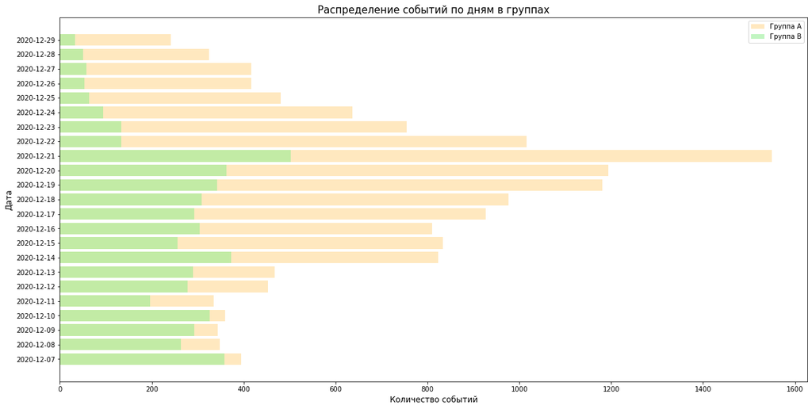

```python
# Подготовим данные для графика
group_day_events = df.pivot_table(index='event_dt', columns='group', values='user_id', aggfunc='count').reset_index()

# Строим график
fig, ax = plt.subplots(figsize=(20,10))
ax.barh(group_day_events['event_dt'], group_day_events['A'], color='orange', label='Группа А', alpha=0.25)
ax.barh(group_day_events['event_dt'], group_day_events['B'], color='lightgreen', label='Группа B', alpha=0.55)

# Добавляем необходимые настройки
ax.set_title('Распределение событий по дням в группах', fontsize=15)
ax.set_ylabel('Дата', fontsize=12)
ax.set_xlabel('Количество событий', fontsize=12)
ax.legend()
ax.set_yticks(group_day_events['event_dt'])
plt.show()
```

- Опять же, `группа A` совершает гораздо больше действий из-за неравномерности;
- Пик в обеих группах приходится на `19-21 декабря`, возможно в это время был наибольший прирост новых пользователей (21 декабря прекращался набор новых пользователей), либо какие-то предновогодние причины.

## Изменение конверсии в группах на разных этапах

```python
# Создадим переменную с информацию по зарегистрированным пользователям в каждой группе
registration_step = (df.groupby('group')
                     .agg({'user_id':'nunique'})
                     .rename(columns={'user_id':'users_num'})
                     .reset_index())

registration_step.insert(1, 'event_name', 'registration')

# Создадим переменную с информацией по действиям  и кол-ву пол-лей, которых их совершили в разрезе группы
agg_funnel = (df.groupby(['group','event_name'],as_index=False)['user_id']
              .nunique()
              .rename(columns={'user_id':'users_num'}))
```

```python
# Соединим созданные ранее таблицы и выстроим правильную последовательность для воронок

# Для группы A
funnel_a = (pd
            .concat([registration_step.loc[0].to_frame().T, agg_funnel.loc[:3]])
            .drop(columns='group')
            .reset_index(drop=True)
            .reindex([0,1,3,2,4])
            .reset_index(drop=True)
           )


# Для группы B
funnel_b = (pd
            .concat([registration_step.loc[1].to_frame().T, agg_funnel.loc[4:]])
            .drop(columns='group')
            .reset_index(drop=True)
            .reindex([0,1,3,2,4])
            .reset_index(drop=True)
           )
```

```python
# Ф-ция вычисляет долю пол-тей на текущем шаге относительно предыдущего и первого и возвращает дф
def funnel_ratio(df,name):

    # Вычисляем долю пользователей на текущем шаге относительно предыдущего шага
    df[f'share_of_previous_step_{name}'] = (df['users_num']/df['users_num'].shift(1,fill_value = df['users_num'].max())*100)
    # Вычисляем долю пользователей на текущем шаге относительно первого шага
    df[f'share_of_initial_step_{name}'] = (df['users_num']/df['users_num'].max()*100)
    # Возвращаем датафрейм
    return df
```

```python
# Создадим ф-цию, которая будет менять формат данных в процентный вид для заданных колонок и возвращать дф

def percentage(df,columns=[]):
    for col in columns:
        df[col] = df[col].map('{0:.2f}%'.format)
    return df
```

```python
# Сделаем необходимые расчеты для группы A

funnel_a_ratio = funnel_ratio(funnel_a,'g_A')
funnel_a_ratio = funnel_a_ratio.rename(columns={'users_num':'g_A'})
```

```python
# Сделаем необходимые расчеты для группы B

funnel_b_ratio = funnel_ratio(funnel_b,'g_B')
funnel_b_ratio = funnel_b_ratio.rename(columns={'users_num':'g_B'})
```

```python
# Объединим группы A и B
funnel_ab_effect = (funnel_a_ratio[['event_name','g_A','share_of_previous_step_g_A']]
                    .merge(funnel_b_ratio[['event_name','g_B','share_of_previous_step_g_B']])
                   )

# Рассчитаем прирост/убыток конверсии шага группы B по отношению к группе A
funnel_ab_effect = funnel_ab_effect[['event_name','g_A','g_B','share_of_previous_step_g_A','share_of_previous_step_g_B']]
funnel_ab_effect['B/A_conv_diff'] = 100*((funnel_ab_effect['share_of_previous_step_g_B'] \
                                          /funnel_ab_effect['share_of_previous_step_g_A'])-1)

# Изменим формат данных для удобства и выведем рез-т
funnel_ab_effect = percentage(funnel_ab_effect,columns=funnel_ab_effect.columns[3:])
funnel_ab_effect
```

|  | event_name | g_A | g_B | share_of_previous_step_g_A | share_of_previous_step_g_B | B/A_conv_diff |
| --- | --- | --- | --- | --- | --- | --- |
| 0 | registration | 2903 | 2196 | 100.00% | 100.00% | 0.00% |
| 1 | login | 2082 | 705 | 71.72% | 32.10% | -55.24% |
| 2 | product_page | 1360 | 397 | 65.32% | 56.31% | -13.79% |
| 3 | product_cart | 631 | 195 | 46.40% | 49.12% | 5.87% |
| 4 | purchase | 652 | 198 | 103.33% | 101.54% | -1.73% |

Исходя из ТЗ, ожидаемым эффектом должно было быть изменение конверсии метрик `product_page` ,`product_cart` и `purchase` не менее чем на **10%** группы B к группе A, но мы видим только незначительный прирост в **5.87%** в конверсии по `product_cart`.

Конверсия на шаге `purchase` более чем в **100%** может нам говорить о том, что пользователи могли пропускать шаг `product_cart` и сразу оформлять заказ.

Опять же, ввиду многочисленных нарушений ТЗ, нам не стоит воспринимать данный результат за истину. Также, для большей наглядности построим график воронки по обеим группам

```python
# Оставим необходимые данные
funnel_ab = funnel_ab_effect[['event_name','g_A','g_B']]


# Строим воронку событий для каждой группы
fig = go.Figure()

fig.add_trace(go.Funnel(
    name = 'Группа A',
    y = funnel_ab['event_name'],
    x = funnel_ab['g_A'],
    textinfo = "value+percent initial+percent previous"))

fig.add_trace(go.Funnel(
    name = 'Группа B',
    y = funnel_ab['event_name'],
    x = funnel_ab['g_B'],
    textposition = 'outside',
    textinfo = "value+percent initial+percent previous"))

# Добавим настройки и выведем график

fig.update_layout(
    title='Воронка действий пользователей, доли прошедших с первого шага и предыдущего шага в разрезе групп',
    yaxis_title="Шаги",
    font=dict(size=11),
    width= 1000,
    height=800
)

# Выводим график
fig.show()
```

[figure not shown]

## Особенности данных, которые нужно учесть перед A/B тестом

Данные для теста были составлены некорректно из-за большого количества нарушений технического задания, перечислим основные проблемы, которые в той или иной степени сказываются на результате:

- Неравномерное распределение пользователей по группам;
- Пересечение пользователей в двух разных тестах;
- Запуск теста в период проведения промоакций, связанных с Новым Годом и Рождеством;
- Ранняя остановка теста;
- Большое кол-во пользователей не имеющих событий кроме регистрации.

# Оценка результатов A/B тестирования

## Результаты A/B теста

- Тест выполнен с нарушением многих пунктов технического задания, что непосредственно влияет на релевантность результата.
- Исходя из полученного результата тестирования мы можем сказать, что внесенные в `группу В` изменения никак не повлияли на воронку в лучшую сторону (ожидаемым эффектом было увеличении конверсии трех метрик на **10%** а именно - `product_page` ,`product_cart` и `purchase`):но по факту видим только незначительный прирост по событию товара в корзину в `5.87%`.
- В целом, мы уже понимаем, что результат теста можно считать провальным, но все же проверим статистическую разницу долей с помощью `z-критерия`.

## Проверка статистической разницы долей z-критерием

Сфррмулируем гипотезы:

- **H₀ (нулевая гипотеза)** - В группах конверсия пользователей по целевому действию равна;
- **H₁ (альтернативная гипотеза)** - В группах конверсия пользователей, по целевому действию различается.

Для проверки гипотез будет использоваться `z-критерий`, но так как мы проводим множественное сравнение (4) мы будем использовать критичекий уровень статистической значимости с учетом `поправки Бонферрони` (в нашем случае делить на 4).

Создадим функцию, которая будет проверять наши гипотезы с учетом `поправки Бонферрони` и далее проведем все тесты.

```python
# Подготовим данные для теста
z_test_df = funnel_ab.set_index('event_name')
```

```python
# Создаем функцию для проведения теста
def test(df,group1, group2, event, n):

    alpha = .05/n # критический уровень статистической значимости с учетом поправки Бонферрони

    successes = np.array([df.loc[event,group1], df.loc[event,group2]])
    trials = np.array([df.loc['registration', group1], df.loc['registration',group2]])

    # пропорция успехов в первой группе:
    p1 = successes[0]/trials[0]

    # пропорция успехов во второй группе:
    p2 = successes[1]/trials[1]

    # пропорция успехов в комбинированном датасете:
    p_combined = (successes[0] + successes[1]) / (trials[0] + trials[1])

    # разница пропорций в датасетах
    difference = p1 - p2

    # считаем статистику в ст.отклонениях стандартного нормального распределения
    z_value = difference / math.sqrt(p_combined * (1 - p_combined) * (1/trials[0] + 1/trials[1]))

    # задаем стандартное нормальное распределение (среднее 0, ст.отклонение 1)
    distr = stats.norm(0, 1)
    p_value = (1 - distr.cdf(abs(z_value))) * 2

    print(f'Проверка для группы A и группы B, событие: {event}, p-значение: {p_value}')

    if (p_value < alpha):
        print("Отвергаем нулевую гипотезу, есть статистически значимая разница между конверсиями пользователей, совершивших данное действие")
    else:
        print("Не получилось отвергнуть нулевую гипотезу, нет статистически значимой разница между конверсиями пользователей, совершивших данное действие")
```

```python
# Переберем все события, кроме регистрации, так как все пользователи по умолчанию уже зарегистрированы
for event in ['login','product_page','product_cart','purchase']:
    test(z_test_df,'g_A','g_B',event,4)
    print()
```

```
Проверка для группы A и группы B, событие: login, p-значение: 0.0
Отвергаем нулевую гипотезу, есть статистически значимая разница между конверсиями пользователей, совершивших данное действие

Проверка для группы A и группы B, событие: product_page, p-значение: 0.0
Отвергаем нулевую гипотезу, есть статистически значимая разница между конверсиями пользователей, совершивших данное действие

Проверка для группы A и группы B, событие: product_cart, p-значение: 0.0
Отвергаем нулевую гипотезу, есть статистически значимая разница между конверсиями пользователей, совершивших данное действие

Проверка для группы A и группы B, событие: purchase, p-значение: 0.0
Отвергаем нулевую гипотезу, есть статистически значимая разница между конверсиями пользователей, совершивших данное действие
```

На всех уровнях воронки событий при проведении `z-теста` гипотезу о равенстве конверсии пользователей в группах не удалось подтвердить. Конверсии имеют статистически значимую разницу.

Но ввиду того, о чем говорилось ранее не стоит воспринимать этот тест ни провальным и ни успешным, так как условия, при которых он проводился были не соблюдены, что напрямую повлияло на нерепрезентативность полученного рез-та.

# Вывод и рекомендации

## Вывод

По результам исследования и в ходе оценки корректности проведения теста, можно сказать лишь то, что тест можно признать провалившимся.

## Рекомендации

Для более корректного принятия решение по поводу новой системы, по возможности, рекомендуется провести новый `A/B тест`, результаты которого действительно можно было бы анализировать и интерпретировать. Для успешного проведения следует:

1. При проведении четко следовать имеющемуся техническому заданию;
2. Рационально подходить к распределнию участников по группам;
3. Не проводить параллельные тесты для одних и тех же пользователей, которые могут в той или иной степени влиять на их действия;
4. Для большей чистоты результатов, проводить отдельно от различных маркетинговых активностей или крупных праздников;
5. Не допускать технических ошибок при наборе пользователей.